# General Linear Model (2)

## Assessing model assumptions

Assumptions:

1. Residuals are normal
2. Variance of residuals is constant

Assessment:

1. QQ plot
2. Plot of Residuals vs Predicted

In practice: care with *influential* outliers!

## Residual plots (with base R plotting system)

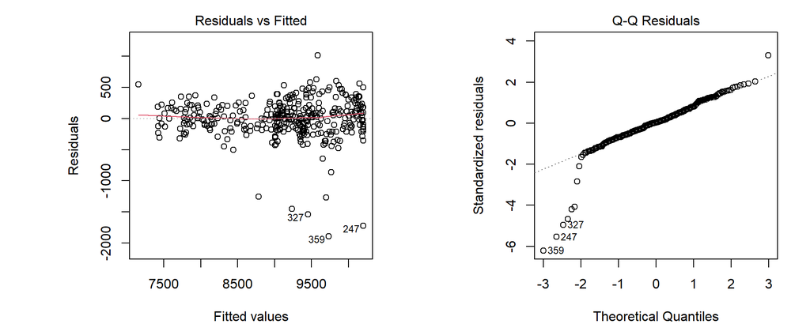

```r
mod_dd <- lm(births ~ day + poly(day_of_year,5), data = d)
par(mfrow = c(1,2), mar = c(4,8,2,2))    # two plots in a slide, margins
plot(mod_dd, 1)                          # residuals vs fitted
plot(mod_dd, 2)                          # QQ plot
```

## Holidays

See [US holidays in 1978](https://www.timeanddate.com/calendar/?year=1978&country=1)

Define new variable `holiday`  
(only for working days to avoid double discounting if weekend!)

```r
h <- as.Date(c("1978-01-02", "1978-02-20", "1978-05-29", "1978-07-04",
               "1978-09-04", "1978-11-11", "1978-11-23", "1978-12-25"))

d <- d %>% mutate(holiday = ifelse(date %in% h & day == "Work",
                    "Yes",
                    "No"))
```

## Adding holidays to the model

```r
mod_ddh <- lm(births ~ day + holiday + poly(day_of_year,5) , data = d); summary(mod_ddh)
```

```
Call:
lm(formula = births ~ day + holiday + poly(day_of_year, 5), data = d)

Residuals:
   Min     1Q Median     3Q    Max
-956.9 -150.0   -4.7  148.8 1059.9

Coefficients:
                      Estimate Std. Error t value Pr(>|t|)
(Intercept)            9576.70      15.50 617.804  < 2e-16 ***
daySat                -1275.78      37.54 -33.986  < 2e-16 ***
daySun                -1623.91      37.25 -43.592  < 2e-16 ***
holidayYes            -1406.86      95.05 -14.801  < 2e-16 ***
poly(day_of_year, 5)1  4770.23     246.48  19.353  < 2e-16 ***
poly(day_of_year, 5)2 -1816.13     246.94  -7.354 1.33e-12 ***
poly(day_of_year, 5)3 -3705.30     246.49 -15.032  < 2e-16 ***
poly(day_of_year, 5)4   617.53     247.62   2.494   0.0131 *
poly(day_of_year, 5)5  3981.23     246.55  16.148  < 2e-16 ***
---
Signif. codes:  0 '***' 0.001 '**' 0.01 '*' 0.05 '.' 0.1 ' ' 1

Residual standard error: 246.5 on 356 degrees of freedom
Multiple R-squared:  0.9112,    Adjusted R-squared:  0.9092
F-statistic: 456.6 on 8 and 356 DF,  p-value: < 2.2e-16
```

## Reassessing assumptions

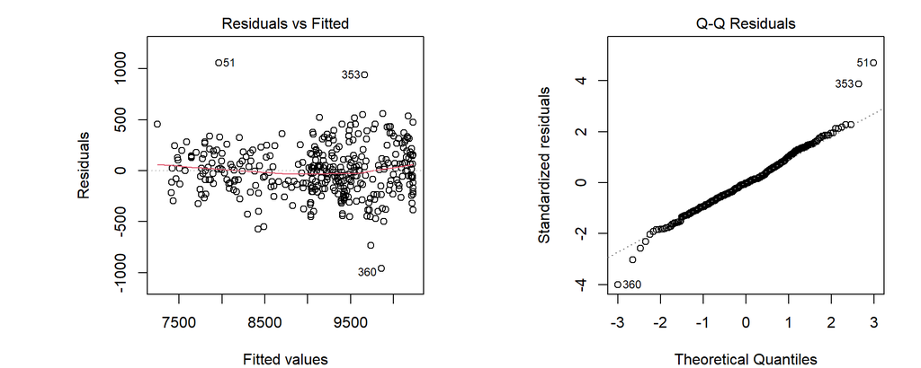

```r
par(mfrow = c(1,2), mar = c(4,8,2,2))
plot(mod_ddh, 1)
plot(mod_ddh, 2)
```

## Inspecting outliers

```r
d %>%
  mutate(residual = resid(mod_ddh)) %>%       # save residuals to d
  slice(51, 353, 360) %>%                      # filters by row number
  select(date, wday, holiday, residual)
```

```
        date wday holiday  residual
1 1978-02-20  Mon     Yes 1059.9280
2 1978-12-19  Tue      No  939.0209
3 1978-12-26  Tue      No -956.9449
```

1978-02-20: \(\quad\) Presidents’ Day, a public holiday in most US states. Nonetheless, many businesses and stores are open.

1978-12-26: \(\quad\) Day after Christmas.

1978-12-19: \(\quad\) ??

## R-squared for the final model

In the plot, `births` and `predicted` are deviations from their means

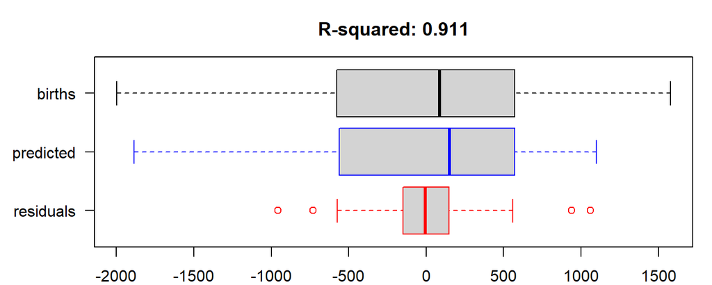

The model explains 91.1 % of the total variation of `births`.  
Not bad!

## Exercise

1. Fit the previous model (`day`, `holiday` and `day_of_year` with 5-degree polynomials).
2. Fit a new model by adding the `day_of_month` to the previous model.
3. Compare the two models by looking at:
   - R-square
   - Adjusted R-squared (which penalizes model complexity)
4. Are the two models nested? If yes, compare them with `anova()`. Does the addition of `day_of_month` improve the fit?